# Some vote patterns in different eras.

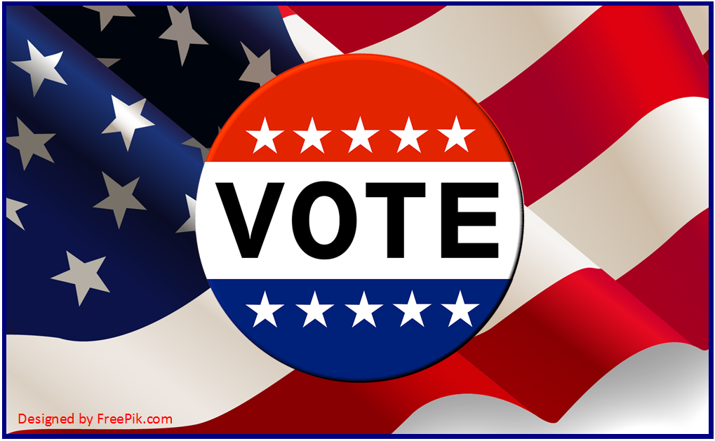

image source: https://trpl.libnet.info/voting-2454

## Introduction

Every four years the US citizens will select their present by voting. Among different groups of people, their preferences in voting might be somehow different. In this analysis, I compared the voting patterns grouped by different education backgrounds in selected years. And I also display how the voting for major or minor third party changed over time. The major problems I tried to answer are:

-Do people of different education backgrounds have preference in voting for specific party.

-Do major or minor third parties get more votes now.

The American National Election Studies are surveys of the US voters from 1948 to 2016. It contains 59944 observations of 1029 variables. In this analysis I only variables about voting year, voting result, turnout and education backgrounds. Moreover, I only need the surveys taken in election years. Then convert the names of variables to meaningful variable names. Therefore, I selected the above variables and created a new dataset called anes_ts. Exclude those observations with no vote results.

## Voting patterns in differenct education backgrounds.

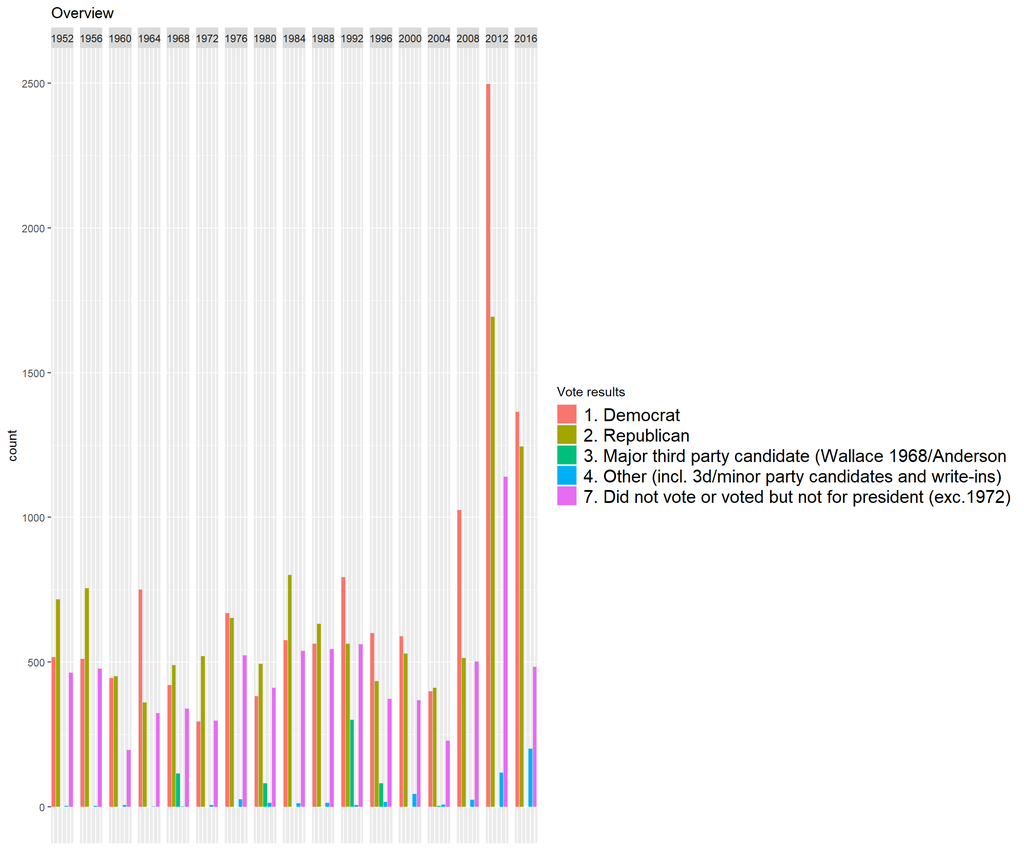

First, let us investigate all the voting results based on this survey from 1952 to 2016. From the histogram above we can see that in 1960, 1976, 2004 and 2016 the numbers of votes for Democrat and Republican were similar. So I will investigate those four years. Because there were little advantages for the winning party, so the differences are likely to be more obvious. Moreover, those four years can represent difference eras.

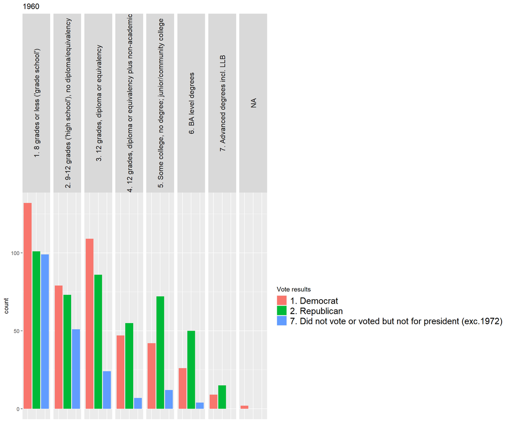

The above histogram is the voting results in 1960. For people finished less than 8 degrees to people finished 12 degrees, diploma or equivalency, they preferred Democrat. For people with higher degrees than 12 degrees, they favored republican more. Especially among people with a college degree or higher degrees, Republican had a huge advantage. The ratio of people who did not vote decreased when the degrees increased.

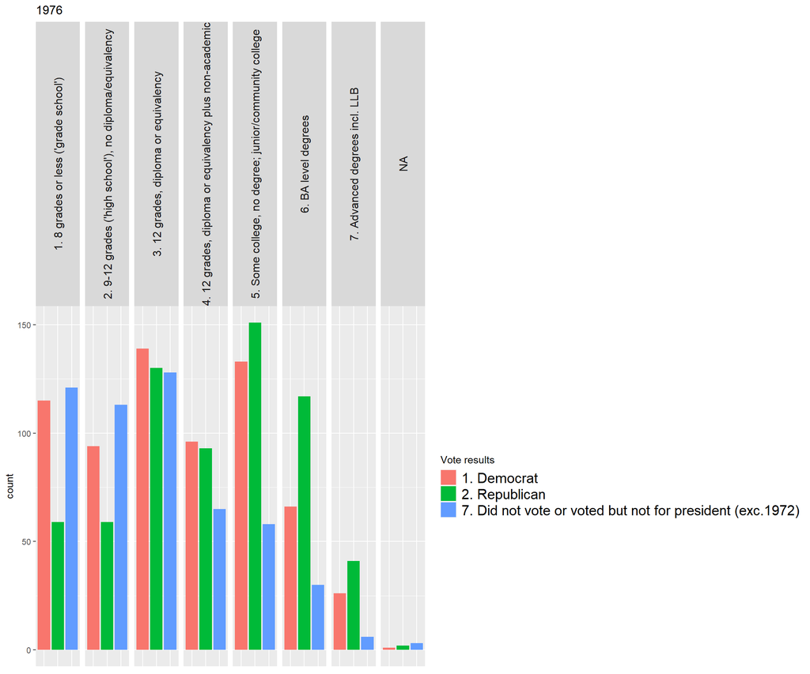

In year 1976 the voting preferences were very similar as those in 1960. However, since it became easier for people to get a relatively high education degrees, the responses in college degrees or higher increased a lot.

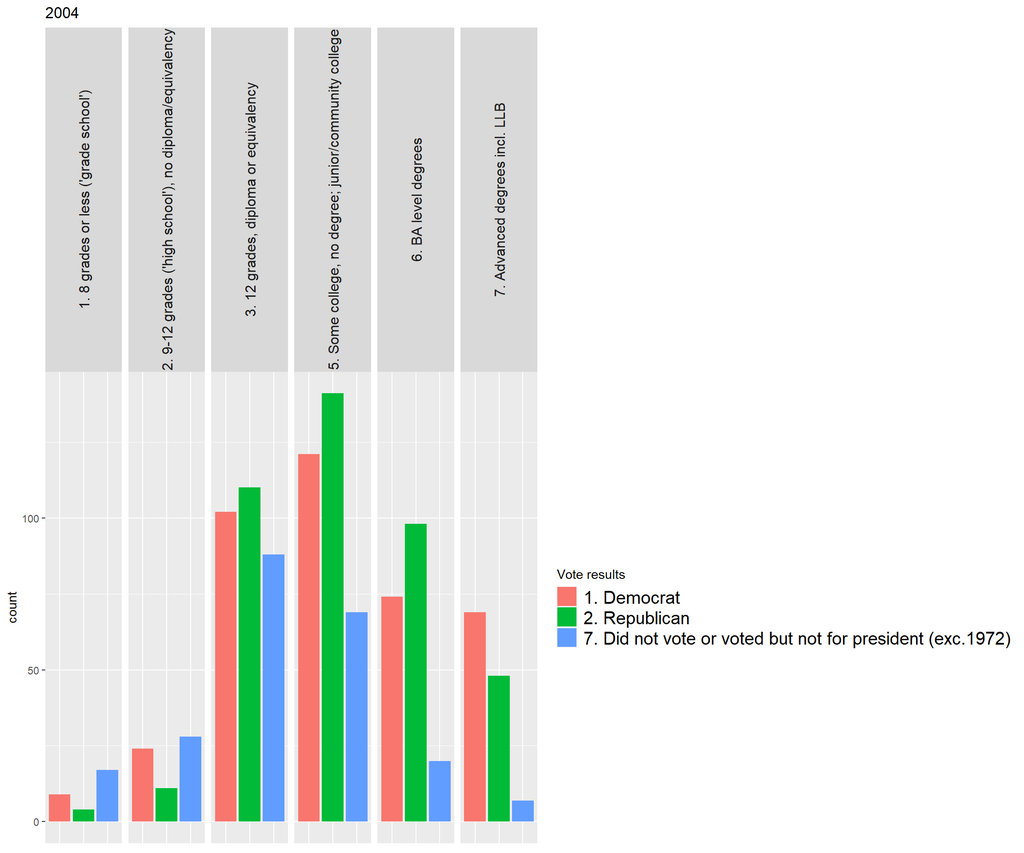

Came to 2004, Republican still had some advantages among people in 12 degrees to BA level degrees. But for people with advanced degrees, which is the highest degrees, their preferences changed from Republican to Democrat.

[figure not shown]

However for the most recent election year in this dataset, the advantages of Republican in high education levels have disappeared. By contrary, democrat had a huge advantage among people with advanced degrees and a small advantage among people with BA level degrees.

## Favors in major or minor parties.

I added two new variables to anes_ts which are “third” and “no_vote”. “third” has two factors which are voting for “1.Major or minor third party” or voting for “2.Other”. And “no_vote” shows whether this people voted or not.

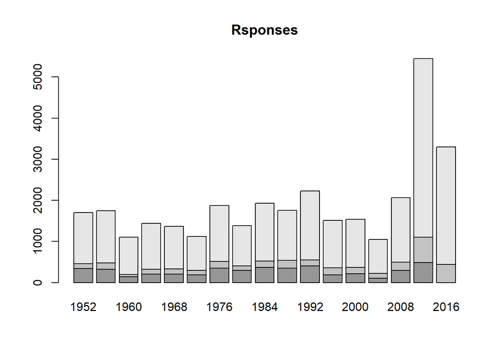

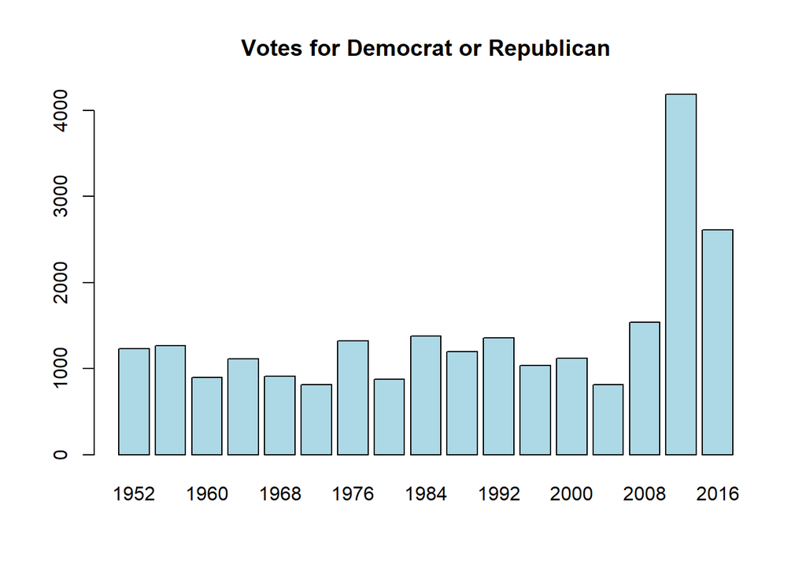

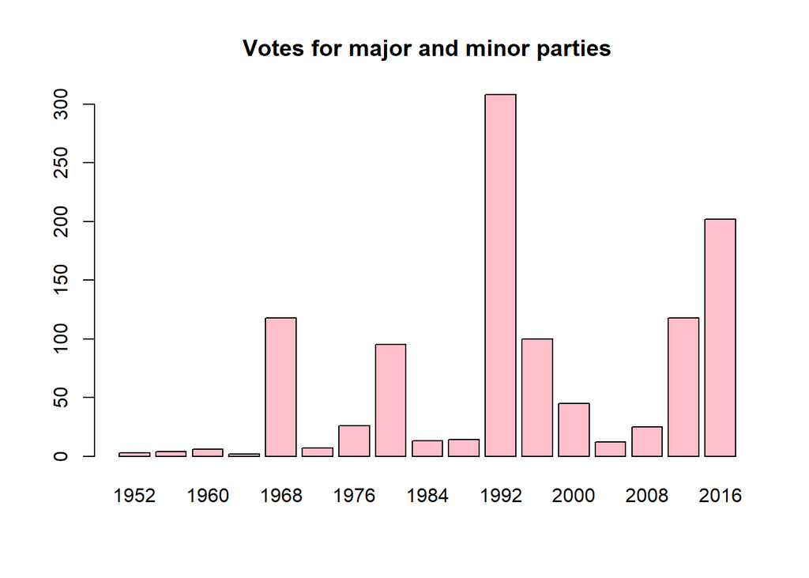

Except for year 2012 and 2016 there is no significant increase in the total responses in this survey. Similarly, the total numbers of votes in this survey for Democrat or Republican have the same shape as the total number of response from 1952 to 2016. However, the votes for major or minor third parties does not have the same shape as the total numbers of responses. Hence, I need to investigates the ratio of votes for major or minor parties in each year.

[figure not shown]

[figure not shown]

## Conclusion

1.People of different education backgrounds generally have different preference for Democrat or Republican. However, those preference are totally different in different eras. Generally speaking, people with higher education levels favored republican in the past. However, more people with higher education levels voted for democrats in recent elections.

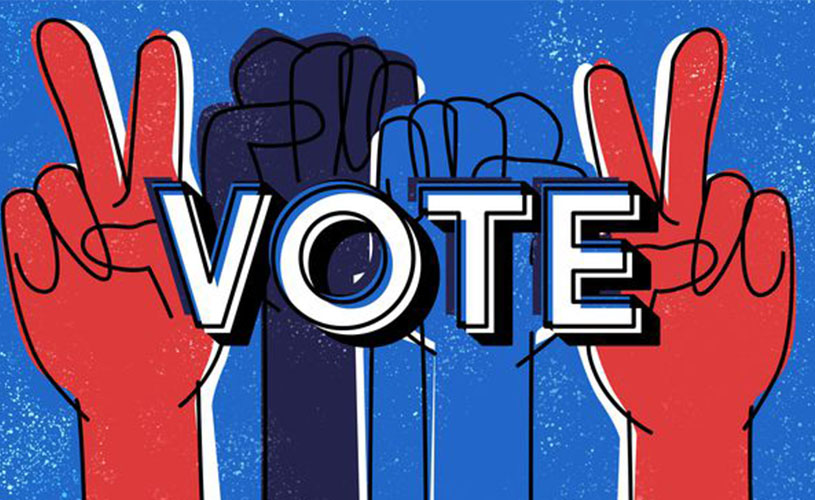

image source:https://eccles.utah.edu/news/why-voting-is-important-as-a-student/